© Guven

# Reinforcement Learning

## Introduction

Reinforcement Learning (RL) is a form of learning from **experience** through reward and penalty.  
The approach plays a role in Artificial Intelligence, Control Theory, Psychology, Neuroscience, and Artificial Neural Networks. What makes this different from supervised learning?

- Supervised Learning: The goal is to minimize an error where the error is the difference between target output and actual output. You can compute the error because you have labeled observations (training data) that you used to build your model.
- Reinforcement Learning: The goal is to maximize the reward given by training **evaluation** (rewards and penalties). The model learns by confronting examples that don't have to exist beforehand (e.g. competing against random players in games).

Reinforcement learning also involves **policy** learning (how to map situations to actions), goal-oriented learning, and learning from interaction (i.e. games).

## Features of RL

- Trial-and-Error search
- Learner decides which actions to take
- The need to balance **exploration** (of unfamiliar strategies) and **exploitation** (of tried-and-true actions)
- The whole problem of a goal-directed **agent** interacting with an uncertain environment
- Might yield to a delayed reward (forgo short-term gains for greater long-term gains)

## Agent Based Learning

Consider an environment and 2 agents:

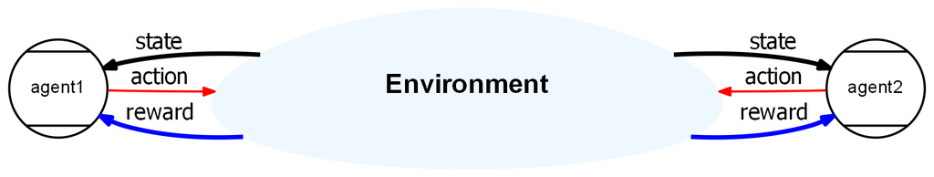

The agent is continuously learning and planning. The objective is to affect the environment which can be stochastic and uncertain. The learner employs a reward/penalty strategy to enable learning. The strength of this strategy also determines the speed of the learning. The learner retains the experience that yields to gain.

## Elements of RL

- Policy: what to do
- Reward: what is good
- Value: what is good because it predicts reward
- Model: what follows what

$\text{Policy} \sqsubset \text{Reward} \sqsubset \text{Value} \sqsubset \text{Model}$

## Examples

**Tic-Tac-Toe** Finite and small number of states; One-step look-ahead is always possible; States are completely observable $\longrightarrow$ Too easy

**TD-Gammon** World's best backgammon playing program

**Elevator Control** High performance down-peak elevator controller (ref: Crites, R. H., Barto, A. G., "Improving elevator performance using reinforcement learning," 1996)

**Dynamic Channel Assignment** High performance assignment of radio channels to mobile telephone calls (ref: Nie, J., Haykin, S., "A dynamic channel assignment policy through Q-learning," 1996)

## Elevator Control Example

Problem

Environment

States

Actions

Rewards

10 floors  
4 elevator cars

Button states, positions  
Directions and motion states of cars  
Passengers in cars and in halls  
There are around $\sim 10^{22}$ number of states

Stop at, or go by, next floor

$\texttt{reward}=–1$ per time step  
for each person waiting

## Games

Games are perfect problems for reinforcement learning.

Tic Tac Toe

Back Gammon

Chess

Go

3D Chess

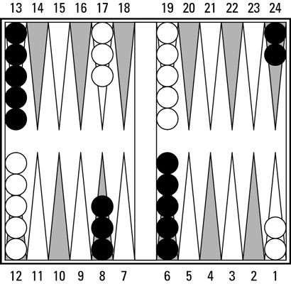

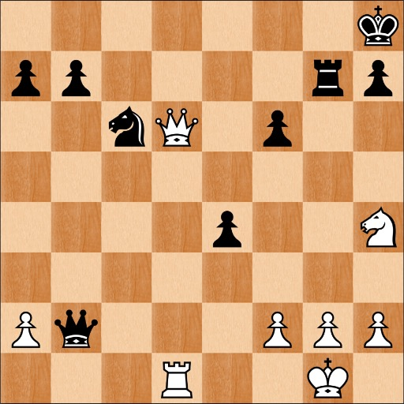

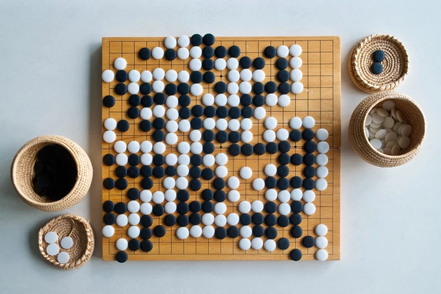

[figure not shown]

**Question:** How many **states** are there for the above games?

**Answer:** (subjective, source: research)

- Tic tac toe: $26,830$ possible games
- Back gammon: $\sim 18,528,584,051,601,162,496$ possible positions
- Chess: $\sim 10^{53}$ possible positions
- Go: $\sim10^{172}$ possible positions
- 3D Chess: Star Trek Tri-Dimensional chess is similar to regular chess except for 3D partition of the board

Estimated number of atoms in the universe= $10^{80}$. And AlphaGo has beaten the human Go champion recently!

Note that although these examples are all deterministic, rather than stochastic, reinforcement learning also works really well with stochastic games, i.e. games that have elements of chance: you could use RL to train a computer program to play Monopoly (which includes dice rolls), poker (which involves drawing cards), etc.

## Evaluative Feedback

**Evaluating** actions $\longleftrightarrow$ **instructing** by giving correct actions

Pure evaluative feedback depends completely on the action taken  
Pure instructive feedback depends not at all on the action taken

Supervised learning is instructive; optimization is evaluative

- Associative: Inputs mapped to Outputs; learn the best output for each input
- Non-associative: *learn* (find) one best Output

*n*-armed bandit - Non-associative, evaluative feedback

## *n*-Armed Bandit Problem

A slot machine is nicknamed a "one-armed bandit." A gambler who has a set amount of money and is trying to allocate that money between machines (which machines to play? in what order? will he play some machine multiple times?) is said to have a "multi-armed bandit problem."

In general, the multi-armed bandit problem involves a fixed, limited set of resources that must be allocated between competing, or alternative, choices in a way that maximizes their expected gain. These gains cannot be immediately computed and, as the learning proceeds, gains (or losses) will materialize. The problem represents the exploration versus exploitation trade-off.

**Q-value:** When an agent takes an action $a$ in state $s$, at time $t$, the predicted future rewards is defined as $Q(s_t,a_t)$

(Note: The term *Q* is not from the Star Trek entity *Q*, but stands for the *Quality* of the action while learning.)

Choose repeatedly from one of n actions where each choice is called a play. After each play $a_t$, you get a reward $r_t$, where $E(r_t|a_t)=Q^*(a_t)$.

Distribution of $r_t$ depends only on $a_t$. Objective is to maximize reward in the long term, e.g. over 1000 plays.

To solve *n*-armed bandit problem we have to **explore** a variety of actions and then **exploit** the best of them.

## Exploration and Exploitation

Greedy action at t is the following:

$a^*_t = \underset{a}{\texttt{argmax}}Q_t(a)$ .................... $(Eq.1)$

$a_t = a^*_t \implies \text{exploitation}$  
$a_t \ne a^*_t \implies \text{exploration}$

Reinforcement learning requires a balance between exploration and exploitation.

## Q-Learning

Based on the Bellman equation, the expected value of states and actions are stored in a table, called the Q-table $Q(s,a)$. The Q-table indicates to the agent (learner) the expected reward for taking action $a$ in state $s$. The values of the Q-table are updated using the equation,

$Q(s,a) \longleftarrow Q(s,a)+ \alpha \ \big(R(s)+ \gamma \ \underset{a'}{\texttt{max}}Q(s',a')-Q(s,a) \big)$ .................... $(Eq.2)$

We can factor out a mutiple of $(1 - \alpha)$ from coefficients of the $Q(s,a)$ term and rearrange that equation:

$Q(s,a) \longleftarrow (1-\alpha)\underbrace{Q(s,a)}_\text{old value} + \underbrace{\alpha}_\text{learning rate} \big(\underbrace{R(s)}_\text{reward} + \underbrace{\gamma}_\text{discount factor} \underbrace{\underset{a'}{\texttt{max}}Q(s',a')}_\text{estimate of optimal future value} \big)$ .................... $(Eq.3)$

The Q values are updated with respect to the action that maximizes expected reward in the successor state with equation, $\underset{a'}{\texttt{max}}Q(s',a')$

$0<\alpha<1$ is learning rate parameter, closer to 1 rewards recent actions more  
$0<\gamma<1$ is discount factor, closer to 1 rewards future actions more  
$R(s)$ is the reward for state $s$

The parameters of the update formula must be tuned in order for the agent to converge to the optimal policy as fast as possible.

## Learning the Nim Game

Nim is a game of strategy between two players in which players remove items from three piles on each turn. Every turn the player must remove at least one item from exactly one of the piles. There are two different versions of the game goal:  
(A.) the player who clears the last pile wins  
(B.) the player who clears the last pile (by removing 1 $\le$ items) loses

For the following Nim game learning example, for simplicity, in this notebook we will consider the goal of the game to be **to clear** the last pile (game (A.) above).

We have three computer-automated players:

1. *Random* player, who moves randomly
2. *Guru* player, who moves according to the Nim solution
3. Q-learner

The following is a simple implementation of the game and the learning strategy. `st[i]` is the state for a pile `i=0,1,2`. The number of piles is hard-coded to 3 and the number of max items per pile is `ITEMS_MX` =10 in the following example. Note that pile symmetry is not handled.

**Note** that updates to the `qtable` should be through the strategy, but not manually as this may break the weights and weight updates the `qtable` that is being accumulated. A consistent weighing across the entire `qtable` is important.

```python
import numpy as np
from random import randint, choice

# The number of piles is 3


# max number of items per pile
ITEMS_MX = 10

# Initialize starting position
def init_game()->list:
    return [randint(1,ITEMS_MX), randint(1,ITEMS_MX), randint(1,ITEMS_MX)]

# Based on X-oring the item counts in piles - mathematical solution
def nim_guru(_st:list)->(int,int):
    xored = _st[0] ^ _st[1] ^ _st[2]
    if xored == 0:
        return nim_random(_st)
    for pile in range(3):
        s = _st[pile] ^ xored
        if s <= _st[pile]:
            return _st[pile]-s, pile

# Random Nim player
def nim_random(_st:list)->(int,int):
    pile = choice([i for i in range(3) if _st[i]>0])  # find the non-empty piles
    return randint(1, _st[pile]), pile  # random move
```

In the following cell the Q-learner is presented. The function makes a move according to the *learned* Q-table. Q-table format is a matrix of type `float` and has dimensions `(number_of_states, possible_moves)` which covers all possible states and actions there can be for the Nim game.

The states are simply a list of the number of items in the 1st pile, the number of items in the 2nd pile, and the number of items in the 3rd pile.  
e.g., `st = [10,10,10]` can be a starting state

The move or action is the tuple of the number of items to remove, and the pile ID.  
e.g., `a = (2,0)` can be an action

For ease of programming and assuring the Q-table does not contain illegal moves (e.g., move (0,0) - not removing an item from a pile) the following table indexing is used:  
`index = pile*ITEMS_MX + move-1` $\longleftrightarrow$ `move, pile = index%ITEMS_MX+1, index//ITEMS_MX`

Note that indexing is 0-based.

The first index part is the pile, i.e. 0, 1, 2. The second index part uses a numbering system, simply based on the number of max items per pile, i.e. using max items of 10. Examples,  
index 2 $\longrightarrow$ move 3, pile 0  
index 11 $\longrightarrow$ move 2, pile 1  
move 10, pile 2 $\longrightarrow$ index 29

**Note:** In RL, the model developer designs the states and the actions (i.e. game move).

```python
def nim_qlearner(_st:list)->(int,int):
    global qtable
    # pick the best rewarding move, equation 1
    a = np.argmax(qtable[_st[0], _st[1], _st[2]])  # exploitation
    # index is based on move, pile
    move, pile = a%ITEMS_MX+1, a//ITEMS_MX
    # check if qtable has generated a random but game illegal move - we have not explored there yet
    if move <= 0 or _st[pile] < move:
        move, pile = nim_random(_st)  # exploration
    return move, pile  # action
```

We will use the engines `nim_guru`, `nim_random` and `nim_qlearner` to play games, as below.

```python
Engines = {'Random':nim_random, 'Guru':nim_guru, 'Qlearner':nim_qlearner}

def game(_a:str, _b:str):
    state, side = init_game(), 'A'
    while True:
        engine = Engines[_a] if side == 'A' else Engines[_b]
        move, pile = engine(state)
        # print(state, move, pile)  # debug purposes
        state[pile] -= move
        if state == [0, 0, 0]:  # game ends
            return side  # winning side
        side = 'B' if side == 'A' else 'A'  # switch sides

def play_games(_n:int, _a:str, _b:str)->(int,int):
    from collections import defaultdict
    wins = defaultdict(int)
    for _ in range(_n):
        wins[game(_a, _b)] += 1
    # info
    print(f"{_n} games, {_a:>8s}{wins['A']:5d}  {_b:>8s}{wins['B']:5d}")
    return wins['A'], wins['B']
```

```python
# Play games
play_games(1000, 'Random', 'Random')
play_games(1000, 'Guru', 'Random')
play_games(1000, 'Random', 'Guru')
play_games(1000, 'Guru', 'Guru') ;
```

```
1000 games,   Random  492    Random  508
1000 games,     Guru 1000    Random    0
1000 games,   Random    6      Guru  994
1000 games,     Guru  931      Guru   69
```

It looks like starting the Nim game first has an advantage for Guru player.

Now let's see how the Q-learner actually learns by the Q-learning algorithm.

Alpha $\alpha$ is set to 1 since Nim game is deterministic and every winning state must be learned.  
For stochastic environments, where events happen randomly or cannot be predicted, alpha is set to less than 1.

```python
qtable, Alpha, Gamma, Reward = None, 1.0, 0.8, 100.0

# learn from _n games, randomly played to explore the possible states
def nim_qlearn(_n:int):
    global qtable
    # based on max items per pile
    qtable = np.zeros((ITEMS_MX+1, ITEMS_MX+1, ITEMS_MX+1, ITEMS_MX*3), dtype=np.float32)
    # play _n games
    for _ in range(_n):
        # first state is starting position
        st1 = init_game()
        while True:  # while game not finished
            # make a random move - exploration
            move, pile = nim_random(st1)
            st2 = list(st1)
            # make the move
            st2[pile] -= move  # --> last move I made
            if st2 == [0, 0, 0]:  # game ends
                qtable_update(Reward, st1, move, pile, 0)  # I won
                break  # new game

            qtable_update(0, st1, move, pile, np.max(qtable[st2[0], st2[1], st2[2]]))

            # Switch sides for play and learning
            st1 = st2

# Equation 3 - update the qtable
def qtable_update(r:float, _st1:list, move:int, pile:int, q_future_best:float):
    a = pile*ITEMS_MX+move-1
    qtable[_st1[0], _st1[1], _st1[2], a] = Alpha * (r + Gamma * q_future_best)
```

Try learning by 1000 games only.

```python
%%time

nim_qlearn(1000)
```

```
CPU times: total: 31.2 ms
Wall time: 40.7 ms
```

```python
# Play games
play_games(1000, 'Qlearner', 'Random')
play_games(1000, 'Random', 'Qlearner')

play_games(1000, 'Random', 'Random') ;
```

```
1000 games, Qlearner  734    Random  266
1000 games,   Random  269  Qlearner  731
1000 games,   Random  503    Random  497
```

As can be seen above our Q-learner learns 'something' and can beat the random player.

Now let's see if the amount of learning has any effect?

```python
%%time

# See the training size effect
n_train = (3, 10, 100, 1000, 10000, 50000, 100000)
Wins = []
for n in n_train:
    nim_qlearn(n)
    wins_a, wins_b = play_games(1000, 'Qlearner', 'Random')
    Wins += [wins_a/(wins_a+wins_b)]
```

```
1000 games, Qlearner  574    Random  426
1000 games, Qlearner  584    Random  416
1000 games, Qlearner  700    Random  300
1000 games, Qlearner  717    Random  283
1000 games, Qlearner  715    Random  285
1000 games, Qlearner  726    Random  274
1000 games, Qlearner  724    Random  276
CPU times: total: 6.22 s
Wall time: 6.27 s
```

```python
# Check the ratio of wins wrt to size of the reinforcement model training
print(Wins)
```

```
[0.574, 0.584, 0.7, 0.717, 0.715, 0.726, 0.724]
```

Learning from even 10 games works but after 100 games our learner actually converges.

**Question:** It looks like our learner does not learn everything that could be learned. How would you modify and update the above code to make the Q-learner actually learns the Nim game and be able to beat the Guru player when it starts as the first player? We will look at this more in the Assignment.

**Note:** The following code helps to debug your Q-learner. Different strategies can be examined by `qtable` comparison.

```python
# Function to print the entire set of states
def qtable_log(_fn:str):
    with open(_fn, 'w') as fout:
        s = 'state'
        for a in range(ITEMS_MX*3):
            move, pile = a%ITEMS_MX+1, a//ITEMS_MX
            s += ',%02d_%01d' % (move,pile)
        print(s, file=fout)
        for i, j, k in [(i,j,k) for i in range(ITEMS_MX+1) for j in range(ITEMS_MX+1) for k in range(ITEMS_MX+1)]:
            s = '%02d_%02d_%02d' % (i,j,k)
            for a in range(ITEMS_MX*3):
                r = qtable[i, j, k, a]
                s += ',%.1f' % r
            print(s, file=fout)

qtable_log('qtable_debug.txt')
```

## References

1. Watkins, Christopher JCH, and Peter Dayan. "Q-learning." Machine learning 8.3 (1992): 279-292.
2. Järleberg, Erik. "Reinforcement learning on the combinatorial game of Nim." (2011).

## Exercises

**Exercise 1.** Examine the Q-table and find columns that are all zero. What are they and why do they exist?

**Exercise 2.** Set the $\alpha = 1$ and $\gamma = 0$. Observe the behavior of the learner and report it.

```python
%%html
<style>
    table {margin-left: 0 !important;}
</style>
<!-- Display markdown tables left oriented in this notebook. -->
```